# Informal Sensitivity Analysis

# Solar….

- questions about the function itself - any line that you didn’t understand

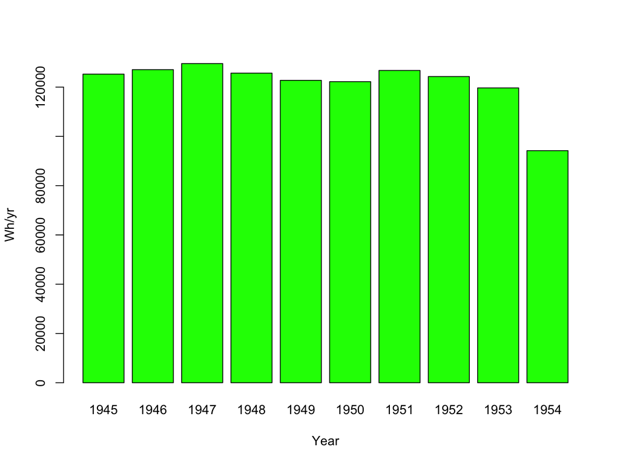

```
## $annual
## # A tibble: 10 × 2
##     year   elect
##    <int>   <dbl>
##  1  1945 125269.
##  2  1946 127086.
##  3  1947 129557.
##  4  1948 125672.
##  5  1949 122743.
##  6  1950 122215.
##  7  1951 126753.
##  8  1952 124288.
##  9  1953 119670.
## 10  1954  94208.
##
## $mean
## [1] 121746
```

```r
source("../R/solarpv.R")


# read in R formatted data
load("../Data/sierraczosolar.rda")

# lets room the first year since we know from last class that it is incomplete

sierraczosolar = sierraczosolar %>% subset(year > 1944)
# run the model
solarpv(area=0.1, solar=sierraczosolar, clr="green", eunit="W")
```

# Sensitivity Analysis with *ethresh*

- Assume +-15% uncertainty in *ethresh* parameter
- Default value from the function is 10,000
- Code so that its easy to change

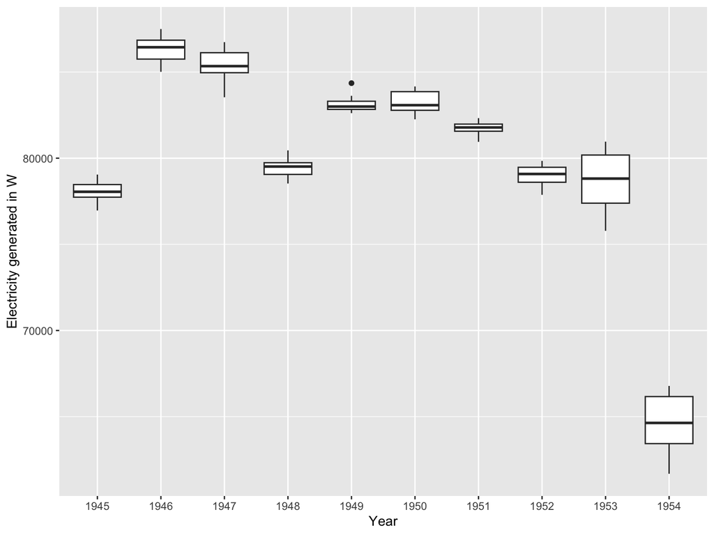

```r
# lets try sensitivity analysis again,
# ethresh - is defaulted to 10000; lets try +- 15%
# lets try 20 samples
# assume a uniform distribution - we don't know anything about variation
deviation = 0.15
base_thresh = 10000
ethresh = runif(min=base_thresh-deviation*base_thresh,
                max = base_thresh+deviation*base_thresh, n=20)

# now run our model for the parameters
site2 = ethresh %>% map(~solarpv( area=0.1,
                      solar=sierraczosolar, clr="green",
                      eunit="W", g=FALSE, etype="direct",
                      ethresh=.x ))


# extract a useful data structure,lets say we want # just the annual data (not the mean), and then reformat as a data frame with nice column names
tmp = map_df(site2,`[`, c("annual"))
site2df = data.frame(year = tmp$annual$year,
                     elect= tmp$annual$elect)

# now we could plot
ggplot(site2df,
       aes(as.factor(year),elect, group=year))+
  geom_boxplot()+
  labs(y="Electricity generated in W", x="Year")
```

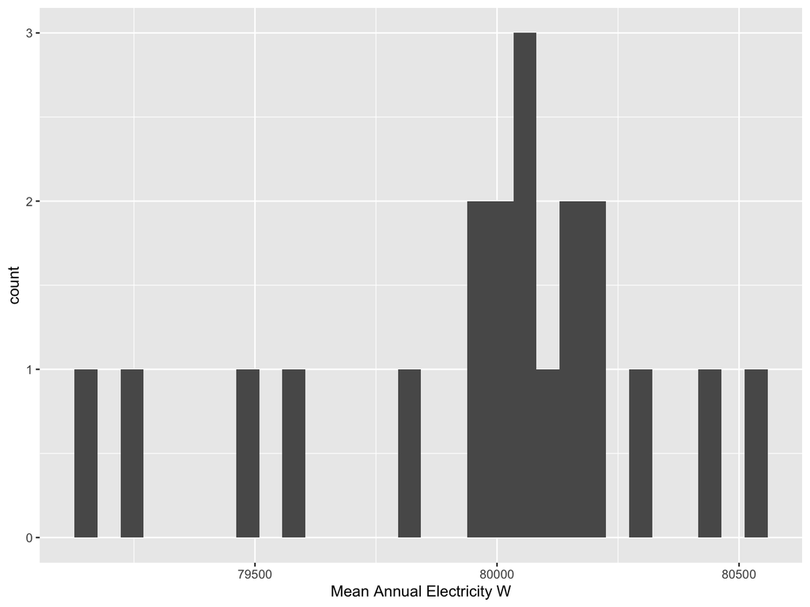

```r
# we also might want to see mean electricity generation across parameter uncertainty
mean_elect = map_df(site2,`[`, c("mean"))
# because there is only 1 value for each ethresh we can add as a column
mean_elect$ethresh = ethresh
# add the efficiency
p1 = ggplot(mean_elect, aes(mean))+geom_histogram()+labs(x="Mean Annual Electricity W")
p1
```

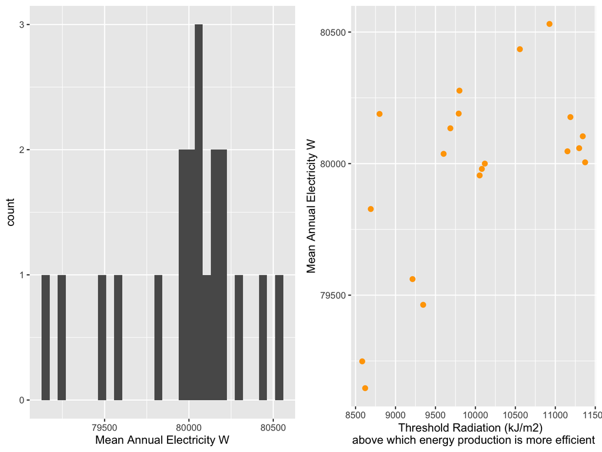

```r
p2 = ggplot(mean_elect, aes(ethresh, mean))+geom_point(cex=2, col="orange")+labs(y="Mean Annual Electricity W", x="Threshold Radiation (kJ/m2)  \nabove which energy production is more efficient")
ggarrange(p1,p2)
```

# Combined sensivitivity analysis

- *eff*
- *ethresh*

Sample from both of them - each time we run the model we vary both of the parameters

# Combined parameter sensitivity

Two possible approaches

- *for*
- *pmap* from purrr

# using *pmap*

```r
# generate samples for both parameters
nsamples = 300
deviation = 0.15
base_thresh = 10000
ethresh = runif(min=base_thresh-deviation*base_thresh,
                max = base_thresh+deviation*base_thresh, n=nsamples)

eff = rnorm(mean=0.6, sd = 0.1, n=nsamples)

parms = cbind.data.frame(eff, ethresh)

# use pmap
# takes function name and then names of all parameters that don't change
results = parms %>% pmap(solarpv,  area=0.1,
                         solar=sierraczosolar, clr="green",
                         eunit="W", g=FALSE, etype="direct")

results[[1]]
```

```
## $annual
## # A tibble: 10 × 2
##     year  elect
##    <int>  <dbl>
##  1  1945 56497.
##  2  1946 63840.
##  3  1947 62938.
##  4  1948 58256.
##  5  1949 60491.
##  6  1950 60737.
##  7  1951 60055.
##  8  1952 57695.
##  9  1953 57842.
## 10  1954 47398.
##
## $mean
## [1] 58575.13
```

```r
length(results)
```

```
## [1] 300
```

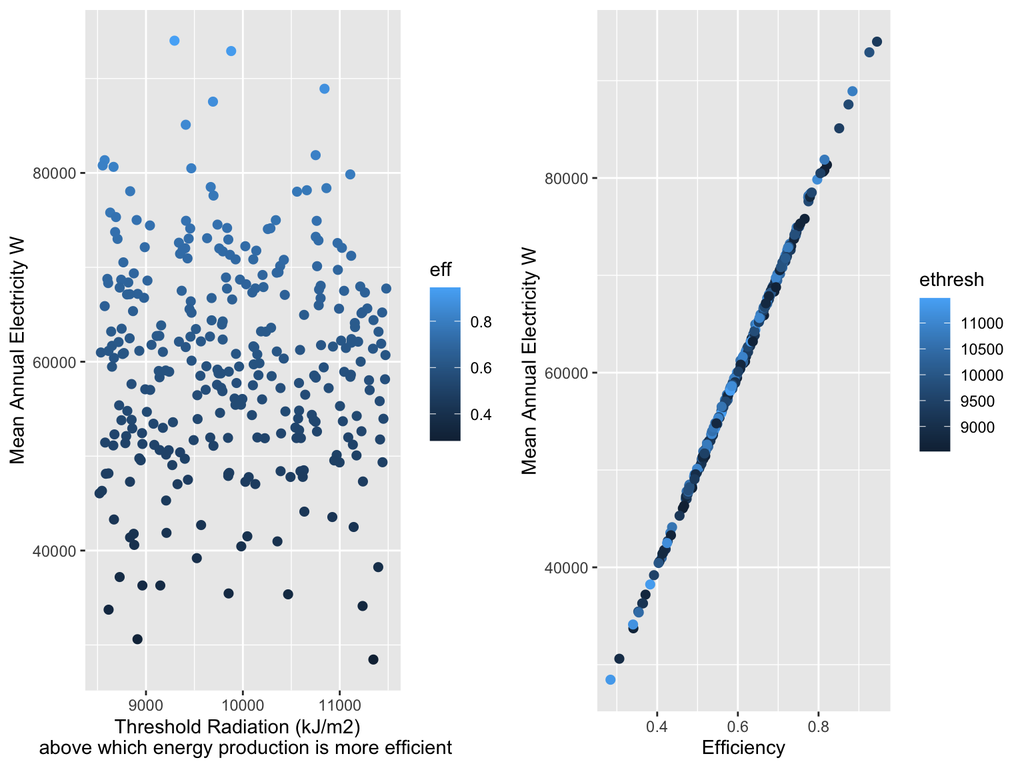

```r
# now we can extract results from the list as above
mean_elect = map_df(results,`[`, c("mean"))
# and we can add the parameter values for each run
mean_elect = cbind.data.frame(mean_elect, parms)

# plot - pick on of the 2 parameter as a color

p1 = ggplot(mean_elect, aes(ethresh, mean, col=eff))+geom_point(cex=2)+
  labs(y="Mean Annual Electricity W", x="Threshold Radiation (kJ/m2)  \n above which energy production is more efficient")
p2 = ggplot(mean_elect, aes(eff, mean, col=ethresh))+geom_point(cex=2)+
  labs(y="Mean Annual Electricity W", x="Efficiency")
ggarrange(p1,p2)
```

```r
# what do we learn from this

# extract annual
tmp = map_df(results,`[`, c("annual"))
annual_elect = as.data.frame(tmp$annual$year)
colnames(annual_elect)="year"
annual_elect$elect = tmp$annual$elect
```

# Using a *For* Loop

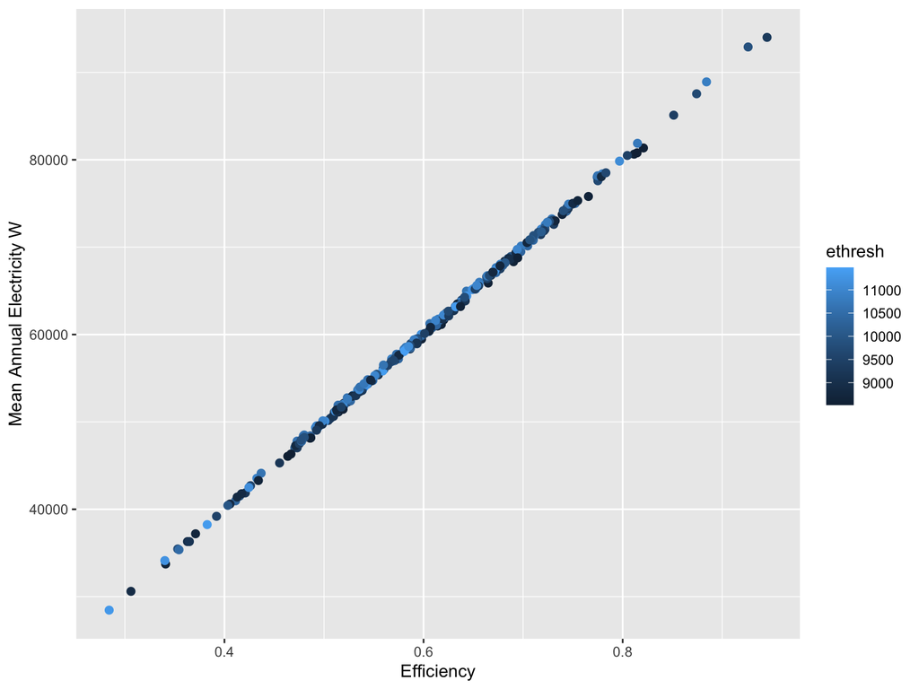

```r
# using a for loop
# start by creating a data structures to hold results, separate
# for scenario mean and annual values
mean_elect_for = rep(NA, times=nsamples)
# for annual we need rows as years, columns for samples
years = unique(sierraczosolar$year)
annual_elect_for = as.data.frame(matrix(ncol=nsamples, nrow=length(years)))
annual_elect_for$year=years


for (i in 1:nsamples) {
  res = solarpv( area=0.1, solar=sierraczosolar,
                 clr="green", eunit="W", g=FALSE, etype="direct",
                 ethresh=parms$ethresh[i],
                 eff = parms$eff[i])

  annual_elect_for[,i] = res$annual$elect
  mean_elect_for[i]= res$mean
}

# plot
me = cbind.data.frame(mean=mean_elect_for, parms)
ggplot(me, aes(eff, mean, col=ethresh))+geom_point(cex=2)+
  labs(y="Mean Annual Electricity W", x="Efficiency")
```

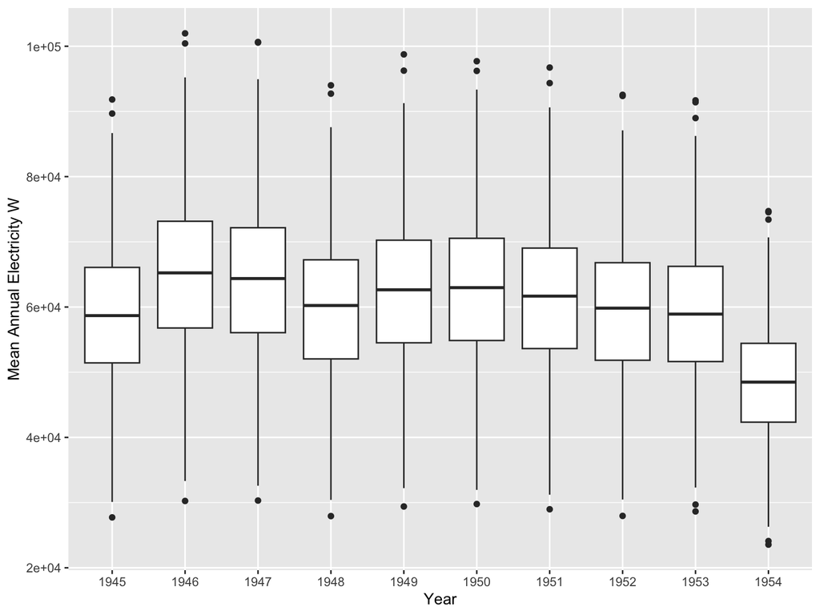

```r
tmp = annual_elect_for %>% pivot_longer(cols=-c(year))

# get rid of that pesky first year
tmp = subset(tmp, tmp$year > 1944)

ggplot(tmp, aes(as.factor(year), value))+
  geom_boxplot()+labs(y="Mean Annual Electricity W", x="Year")
```

# Building models with blocks - functions that call other functions

Functions can always embed other functions - and in models the output of one model may be the input to another

- loosely coupled models - output from one becomes input the other - but not necessarily automatic
- fully coupled - models exchange input sna outputs (feedback systems)

Develop a flow diagram

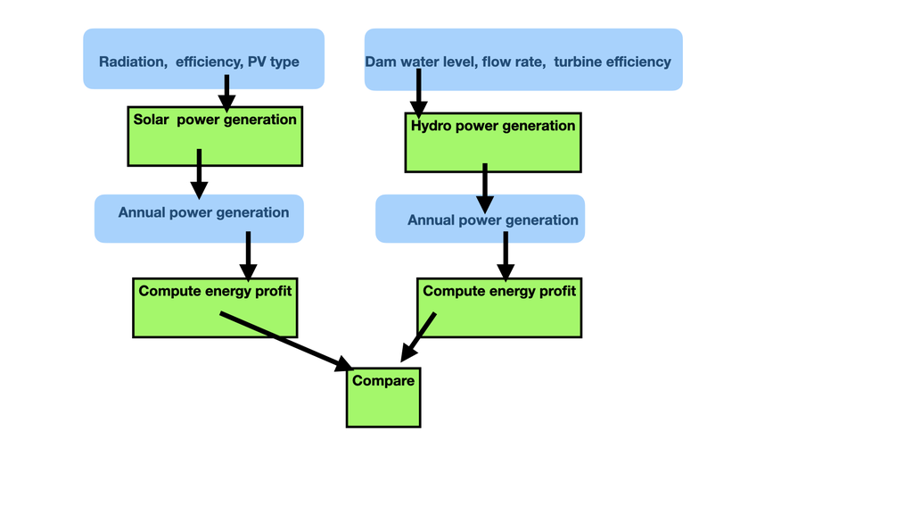

# Reusing boxes

To start - lets create what we need to compute net present value of power generated for multiple years

- compute_profit_frompower.R

We will use output from our solarpv function as input into a function that estimates profit given a price - and also ‘calls’ another function to compute net present value

- compute_NPV
  - inputs: value, time, discount rate
  - output net present value of input value provide as some time in the future
- compute_profit_frompower
  - inputs: energy, year (energy was produced in) price, discount rate
  - outputs: single dataframe with columns for
    - energy
    - year
    - net (profit from energy in that year)
    - netpre (net present value of that profit)

```r
source("../R/compute_NPV.R")
source("../R/compute_profit_frompower.R")

compute_profit_frompower
```

```
## function (energy, year, price, discount = 0.12)
## {
##     if (length(energy) < 1)
##         return(NA)
##     if (min(energy) < 0)
##         return(NA)
##     scen = seq(from = 1, to = length(energy))
##     yearprofit = data.frame(scen = scen, energy = energy, year = year)
##     yearprofit$net = yearprofit$energy * price
##     yearprofit = yearprofit %>% mutate(netpre = compute_NPV(value = net,
##         time = year - year[1], discount = discount))
##     return(yearprofit)
## }
```

```r
compute_NPV
```

```
## function (value, time, discount = 0.12)
## {
##     result = value/(1 + discount)^time
##     return(result)
## }
```

```r
# use solar from  site1 from above as input
head(annual_elect)
```

```
##   year    elect
## 1 1945 56497.40
## 2 1946 63840.49
## 3 1947 62938.31
## 4 1948 58256.49
## 5 1949 60490.55
## 6 1950 60737.37
```

```r
profit_solar = compute_profit_frompower(energy=annual_elect$elect,
                                        year=annual_elect$year,
                                        price=30, discount=0.04)

head(profit_solar)
```

```
##   scen   energy year     net  netpre
## 1    1 56497.40 1945 1694922 1694922
## 2    2 63840.49 1946 1915215 1841552
## 3    3 62938.31 1947 1888149 1745700
## 4    4 58256.49 1948 1747695 1553694
## 5    5 60490.55 1949 1814716 1551227
## 6    6 60737.37 1950 1822121 1497651
```

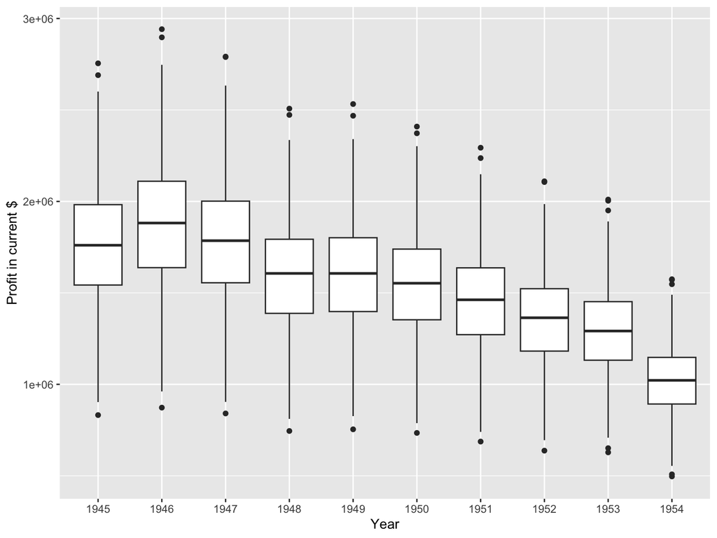

```r
profit_solar = subset(profit_solar, year > 1944)

ggplot(profit_solar, aes(as.factor(year), netpre, group=year))+geom_boxplot()+
  labs(y="Profit in current $", x="Year")
```

# Putting it all together

Full picture of power options

- run *compute_profit_frompower* for both hydro and solar power
- include sensitivity analysis to account for parameter undertainty in both

Notice that we can ‘re-use’ our functions such as *compute_profit_frompower* for both sources of power (such as our reservoir power model) to build out our complete picture

# Why?

- Allows us to compare scenarios, accounting for parameter uncertainty
- Illustrates a general workflow
  - design your model - reusing where possible
  - accounting for parameter uncertainty
  - graphing to analyze results

# Code

```r
# repeating what we did before
# lets start with hydro power
source("../R/power_gen.R")

# we are 'making up' inputs for hydro power - to have it match the number of year
# that we had solar values for, lets sets the number of runs equal to the number of years

number_years = length(profit_solar$year)

reservoir_model_res= as.data.frame(matrix(nrow=number_years, ncol=3))

colnames(reservoir_model_res)=c("height","flow","power")

# Step 2 - generate heights and flow rates
reservoir_model_res$height = rnorm(mean=10, sd=1, n=number_years)

reservoir_model_res$flow = runif(min=0.1, max=1, n=number_years)

# Step 3 - generate uncertainty due to reservoir efficiency, lets assume that
# we know its somewhere between 0.4 and 0.7
Keff = runif(min=0.4, max=0.7, n=20)

# Step 3 - apply model to get power for each height, flow rate (each year), across
# uncertainty in efficiency
reservoir = Keff %>% map_dfc(~power_gen(
  height=reservoir_model_res$height,
  flow=reservoir_model_res$flow, Keff=.x) )
colnames(reservoir)=Keff

head(reservoir)
```

```
## # A tibble: 6 × 20
##   0.5641710689…¹ 0.493…² 0.434…³ 0.627…⁴ 0.592…⁵ 0.459…⁶ 0.661…⁷ 0.571…⁸ 0.597…⁹
##            <dbl>   <dbl>   <dbl>   <dbl>   <dbl>   <dbl>   <dbl>   <dbl>   <dbl>
## 1         38425.  33588.  29584.  42727.  40342.  31298.  45049.  38929.  40676.
## 2         32191.  28139.  24784.  35795.  33797.  26220.  37740.  32613.  34077.
## 3         16454.  14383.  12669.  18297.  17275.  13403.  19291.  16670.  17418.
## 4          8899.   7779.   6851.   9895.   9343.   7248.  10433.   9016.   9420.
## 5         43282.  37833.  33323.  48127.  45441.  35254.  50742.  43849.  45817.
## 6         28150.  24606.  21673.  31301.  29554.  22929.  33002.  28519.  29799.
## # … with 11 more variables: `0.481956432503648` <dbl>,
## #   `0.508566390094347` <dbl>, `0.552440310432576` <dbl>,
## #   `0.575060655479319` <dbl>, `0.655506764655001` <dbl>,
## #   `0.46742631806992` <dbl>, `0.480534043442458` <dbl>,
## #   `0.650684877950698` <dbl>, `0.61807285931427` <dbl>,
## #   `0.657536515919492` <dbl>, `0.462800946342759` <dbl>, and abbreviated
## #   variable names ¹`0.564171068975702`, ²`0.493155220570043`, …
```

```r
# add years - remember we are making up data for the same years that we have solar
reservoir$year = profit_solar$year

# reorganize for easier analysis
reservoirg=as.data.frame(reservoir) %>% pivot_longer(!year,names_to="Keff", values_to="power")
head(reservoirg)
```

```
## # A tibble: 6 × 3
##    year Keff               power
##   <int> <chr>              <dbl>
## 1  1945 0.564171068975702 38425.
## 2  1945 0.493155220570043 33588.
## 3  1945 0.434363009803928 29584.
## 4  1945 0.62733666212298  42727.
## 5  1945 0.592318682791665 40342.
## 6  1945 0.45952923912555  31298.
```

```r
# create profit from hydro
profit_hydro = compute_profit_frompower(energy=reservoirg$power, year= reservoirg$year, price=30, discount=0.04)

names(profit_hydro)
```

```
## [1] "scen"   "energy" "year"   "net"    "netpre"
```

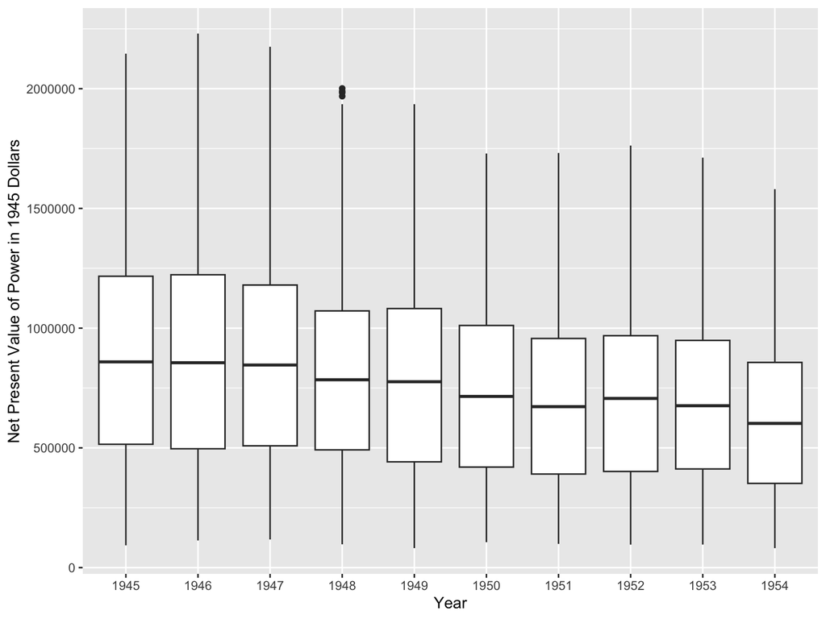

```r
# plot
ggplot(profit_hydro, aes(as.factor(year), netpre, group=year))+geom_boxplot()+labs(y="Net Present Value of Power in 1945 Dollars", x="Year")
```

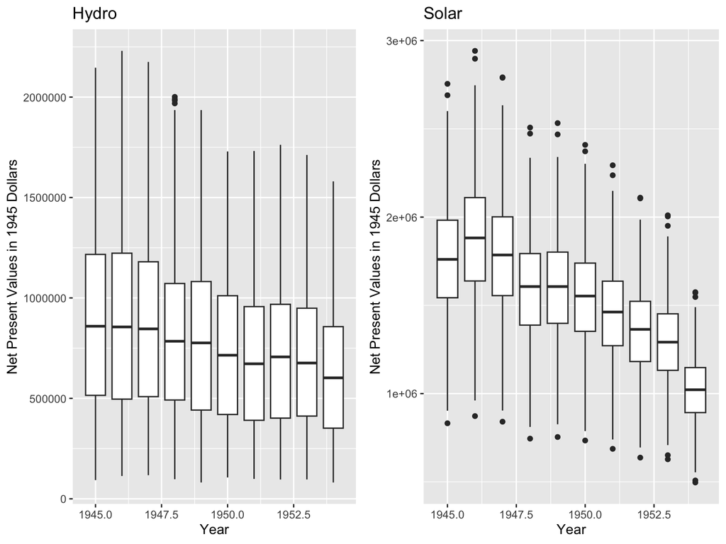

```r
# compare with solar
a=ggplot(profit_hydro, aes(year, netpre, group=year))+geom_boxplot()+labs(title="Hydro",y="Net Present Values in 1945 Dollars", x="Year")
b=ggplot(profit_solar, aes(year, netpre, group=year))+geom_boxplot()+labs(title="Solar", y="Net Present Values in 1945 Dollars", x="Year")
ggarrange(a,b)
```

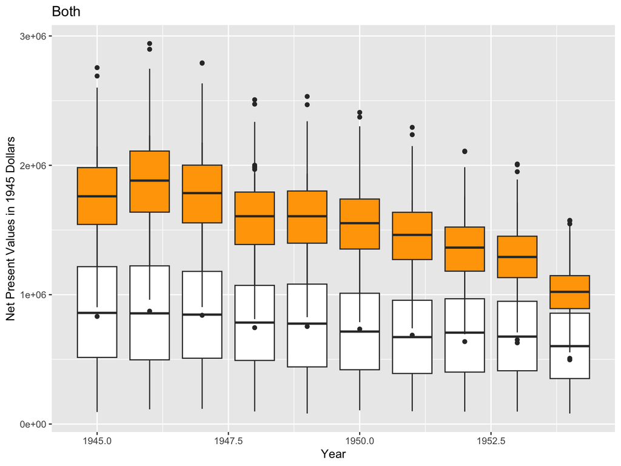

```r
# put on one graph
ggplot(profit_hydro, aes(year, netpre, group=year))+geom_boxplot()+labs(y="Net Present Values in 1945 Dollars", x="Year", title="Both") +
  geom_boxplot(data=profit_solar, aes(year, netpre, group=year), fill="orange")
```

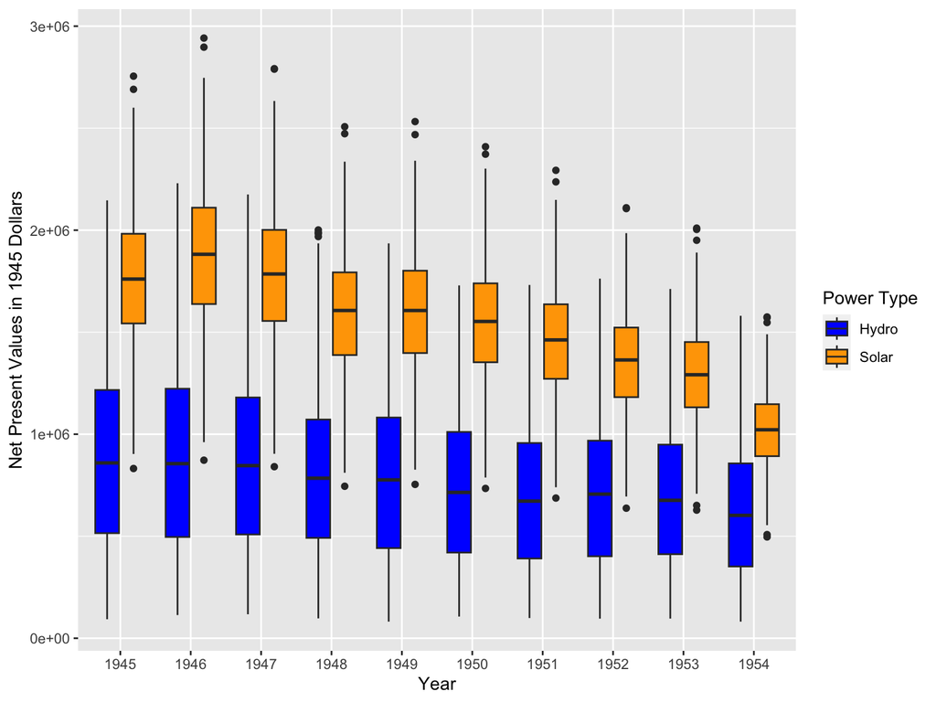

```r
# or do get a nice legend
profit_hydro$etype="Hydro"
profit_solar$etype="Solar"
tmp = rbind.data.frame(profit_hydro, profit_solar)
ggplot(tmp, aes(as.factor(year), netpre, fill=etype))+geom_boxplot()+labs(y="Net Present Values in 1945 Dollars", x="Year", fill="Power Type")+scale_fill_manual(values=c("blue","orange"))
```

# Assignment 3

In your same groups -

- Develop a profit model for your almond yield (you can make this up - think about what the parameters would be)
  - you might assume a baseline profit and then adjust according to the anomaly
  - there are many ways to combine the almond yield and profit functions; you can have the profit function “call”/use the almond yield function; or create a wrapper function that calls them in sequence (first the almond yield and then the profit function)
- Do a simple informal sensitivity analysis of almond yield profit using at least 2 parameters
- Create a single graph of the results - you can decide what is the most meaningful graph

Submit as a group: an Rmarkdown document, your R files for almond yield and profit model, and Graph on Canvas-